# Network analysis

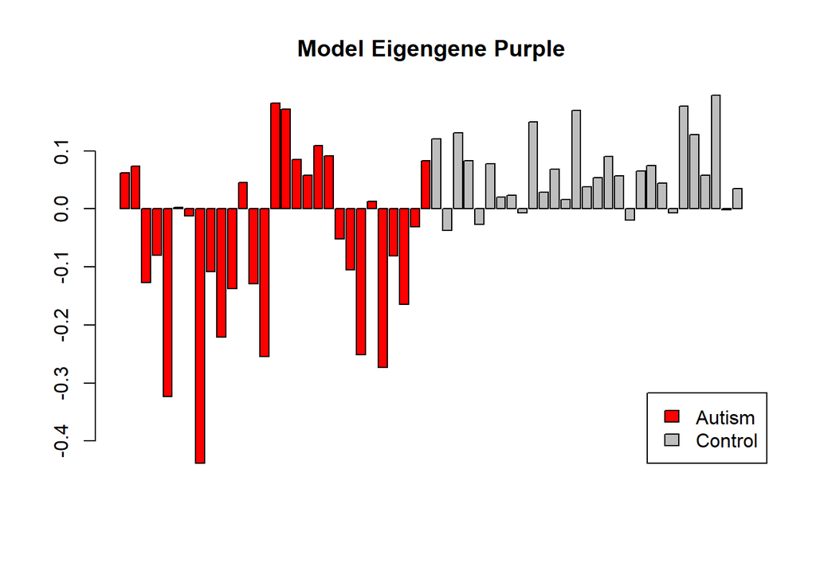

```r
df <- data.frame(modules$MEs[c("MEpurple", "MEtan", "MEdarkgreen", "MEblack", "MElightyellow", "MEcyan")], hasAutism)

colors = c("grey", "red")
# then we plot with inedxing

barplot(df$MEpurple[idx], main= "Model Eigengene Purple" ,col = colors[as.factor(df$hasAutism[idx])])
legend("bottomright", legend = c("Autism", "Control"), fill = c("Red", "Grey"))
```

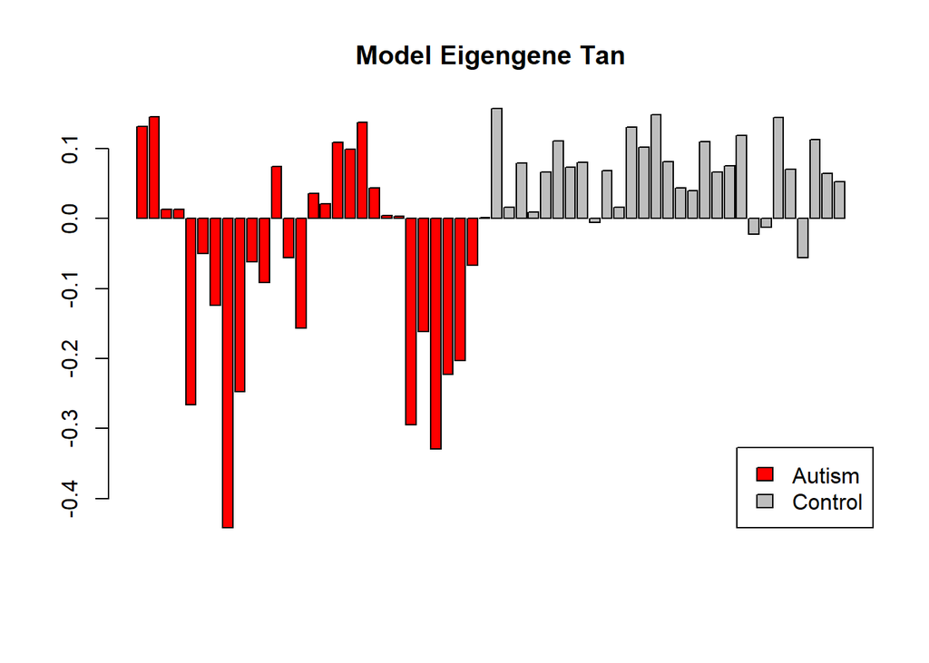

```r
barplot(df$MEtan[idx], main= "Model Eigengene Tan" ,col = colors[as.factor(df$hasAutism[idx])])
legend("bottomright", legend = c("Autism", "Control"), fill = c("Red", "Grey"))
```

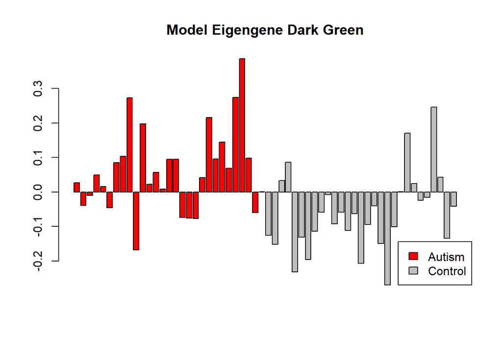

```r
barplot(df$MEdarkgreen[idx], main= "Model Eigengene Dark Green" ,col = colors[as.factor(df$hasAutism[idx])])
legend("bottomright", legend = c("Autism", "Control"), fill = c("Red", "Grey"))
```

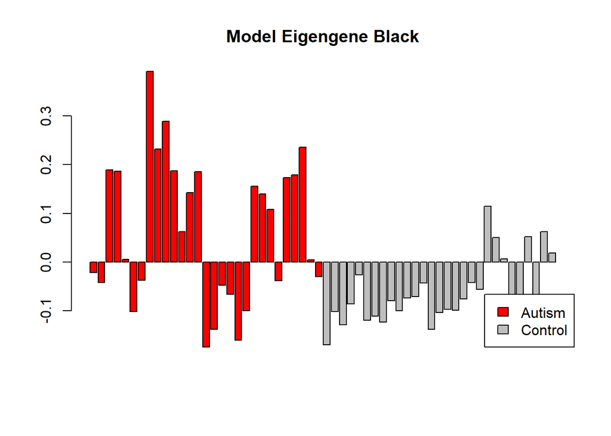

```r
barplot(df$MEblack[idx], main= "Model Eigengene Black" ,col = colors[as.factor(df$hasAutism[idx])])
legend("bottomright", legend = c("Autism", "Control"), fill = c("Red", "Grey"))
```

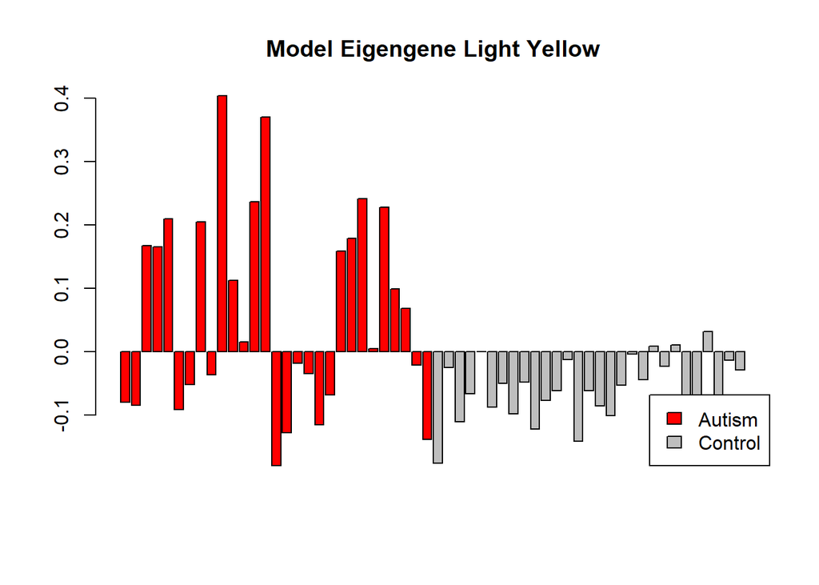

```r
barplot(df$MElightyellow[idx], main= "Model Eigengene Light Yellow" ,col = colors[as.factor(df$hasAutism[idx])])
legend("bottomright", legend = c("Autism", "Control"), fill = c("Red", "Grey"))
```

Instead of a binary module membership, where a gene is either a member of a module or not, we can also calculate a continuous measure of membership. In WGCNA, continuous module membership can be computed as the Pearson correlation between a gene’s expression profile and each module eigengene. This can be thought of as a measure of how central that gene is to each of the modules. The module membership of all genes can be calculated like this:

```r
# Measure module membership by calculating the correlation between genes and module eigengenes
kME <- cor(exp, modules$MEs)
kME <- as.data.frame(kME) # Convert to a data.frame

symbols <- data.frame(fData(bsd.cortex.norm)$SYMBOL)
Purple.genes <- data.frame(kME$MEpurple, symbols)
# Sort by correlation
Purple.genes <- Purple.genes[order(-Purple.genes$kME.MEpurple), ]
Central.genes <- Purple.genes[1:10, ]
```

*Get the names of the ten most central genes (highest kME) from the M12-like module you found above (Hint: Create a table with two columns: scores from the kME-table from the right module and the gene names from fData(bsd.cortex.norm)$SYMBOL. These two tables have genes organized in the same order! Then sort by score). Do you recognize any of the genes from the center of Voineagu figure 2-B in your results? (Note that the gene A2BP1 is also known as RBFOX1.)*

In the Voineagu article, they find that the M12 module has significant over-representation of autism susceptibility genes. On Canvas you can find the file supDataASDgenes.txt which contains a tab separated table of autism susceptibility genes (taken from the article’s supplementary table 10).

```r
ASDtbl <- read.table("supDataASDgenes.txt", header = TRUE, sep="\t", stringsAsFactors = FALSE)
```

In the article, they used the hyper-geometric test to test for over-representation in modules. They defined a gene to be in a module if their module membership was high (kME > 0.7).

The parameters we need to perform a hyper-geometric test are: + the number of autism susceptibility genes in the module + the number of autism susceptibility genes (in the entire data set) + the number of genes that are not autism susceptibility genes (in the entire data set) + the number of genes in the module.

Study the help page of the phyper-function. The hypergeometric test is described as drawing balls from an urn containing white and black balls. Describe the four parameters above in the language used in the help pages.

Because there is not a 1:1 mapping between probes and genes we have to handle that properly. Firstly, probes that do not have a gene symbol are ignored. Secondly, the genes that have several probes will have several module membership values, these will be handled by calculating the mean value for all probes.

Go through and try to understand the script below. Look at what the apply() and tapply() functions do.

```r
# Get the unique gene names present in the cortex data
genesCortex <- na.omit(unique(fData(bsd.cortex.norm)$SYMBOL))

# Get autism susceptibility genes that are also present in the cortex data (using %in% to compare lists)
genesASD <- ASDtbl$Gene[ASDtbl$Gene %in% genesCortex]

m <- length(genesASD) # number of ASD genes
n <- length(genesCortex) - m # number of non-ASD genes

# Calculate the probability of modules being enriched with austism susceptibility genes
p.value <- apply(kME, 2, function(kMEcolumn){
  # Map probes to gene names, calculating per gene the mean of the probes' module membership value
  gene.kME <- tapply(kMEcolumn, fData(bsd.cortex.norm)$SYMBOL[, drop = TRUE], mean)
  # How many genes in module, above the cutoff score
  k <- sum(gene.kME > 0.7)
  # How many ASD genes in module, above the cutoff score
  kASD <- sum(gene.kME[genesASD] > 0.7)
  # The probability of having that many ASD genes in the module by chance (hyper-geometric test)
  return(1 - phyper(kASD - 1, m, n, k))
})
p.value <- p.value[order(p.value)] # Order by significance

# Adjust pvalues for multiple testing
p.adj <- p.adjust(p.value, method="fdr")
```

*From the article: “Remarkably, unlike differentially expressed genes, M12 showed significant overrepresentation of known autism susceptibility genes2 (Supplementary Table 10; P = 6.1E-4)”. Try to explain how the network analysis was able to do what the differential expression analysis was not able to do.* In assignment 4 I said: Based on the clustering results I dont think the differential expression analysis has sucessfully identified gene expression changes associated with autism. This is because more than just the log fold change explains the difference in expressed genes. We also have to account for correlation between the different variables as well.

In this analysis we have done precisely that! We have taken the correlation between genes into account giving rise to a more precise answer. Genes are mostly co-expressed and so it would be more logical to infer that in an analysis.